# CRÉDIT SCORING

## Feature Engineering Avancé

Projet CLF02 - "Prêt à dépenser"

## 📚 1. ÉTAT DE L'ART & DOCUMENTATION

### 🔬 Revue de la littérature - Credit Scoring

#### 1. Fondements historiques - Altman Z-Score (1968)

Le modèle Z-Score d'Altman reste une référence en analyse du risque de crédit. Il utilise **5 ratios financiers** pour prédire la faillite :

- **X1** = Working Capital / Total Assets (Liquidité)
- **X2** = Retained Earnings / Total Assets (Rentabilité cumulée)
- **X3** = EBIT / Total Assets (Productivité des actifs)
- **X4** = Market Value of Equity / Total Liabilities (Solvabilité)
- **X5** = Sales / Total Assets (Rotation des actifs)

*Adaptation pour notre cas : ratios Credit/Income, Annuity/Income, Credit/Goods*

#### 2. KazukiOnodera - Kaggle 7th Place Solution (AUC ~0.805)

**Techniques clés extraites de [son repo GitHub](https://github.com/KazukiOnodera/Home-Credit-Default-Risk) :**

- **Agrégations par fenêtre temporelle** : all, 1y, 2y, 3y séparément
- **Target Encoding avec K-Fold CV** : évite le data leakage
- **Features Lag/Shift** : cumul des comportements décalés
- **Diff & PctChange** : dynamique temporelle (variation mois à mois)
- **First/Last records** : premier et dernier crédit du client
- **STATUS distribution** : comptage des statuts Bureau Balance (0,1,2,3,4,5,C,X)
- **Stratification** : agrégations par statut contrat, yield group, canal

#### 3. Best Practices Feature Engineering (2024-2025)

Selon la littérature récente (Springer AI Review 2025) :

- **Ratios financiers** : DTI (Debt-to-Income), Payment-to-Minimum, Credit Utilization
- **Variables temporelles** : ancienneté emploi, âge du crédit, délais de paiement
- **Interactions** : INCOME × EDUCATION, OCCUPATION × ORGANIZATION
- **PCA** : réduction dimensionnelle pour variables corrélées (immobilier)

*Source : [ML Credit Scoring - Springer 2025](https://link.springer.com/article/10.1007/s10462-025-11416-2)*

### 🎯 Stratégie de Feature Engineering adoptée (Améliorée)

*⭐ = Améliorations inspirées de KazukiOnodera*

## 📦 2. SETUP & CHARGEMENT DES DONNÉES

```python
# Imports
import pandas as pd
import numpy as np
import matplotlib.pyplot as plt
import seaborn as sns
import warnings
from pathlib import Path
from sklearn.preprocessing import LabelEncoder, PolynomialFeatures
from sklearn.impute import SimpleImputer
import gc

# Configuration
warnings.filterwarnings('ignore')
pd.set_option('display.max_columns', None)
pd.set_option('display.max_rows', 100)
pd.set_option('display.float_format', '{:.4f}'.format)

# Style
plt.style.use('seaborn-v0_8-darkgrid')
sns.set_palette("husl")
plt.rcParams['figure.figsize'] = (12, 6)

print("✓ Imports réussis")
```

```
✓ Imports réussis
```

```python
# Chargement des données
DATA_PATH = Path('../Data')

print("Chargement des données...")
app_train = pd.read_csv(DATA_PATH / 'application_train.csv')
app_test = pd.read_csv(DATA_PATH / 'application_test.csv')

print(f"✓ Train : {app_train.shape[0]:,} × {app_train.shape[1]}")
print(f"✓ Test  : {app_test.shape[0]:,} × {app_test.shape[1]}")

# Sauvegarde des IDs et TARGET
train_ids = app_train['SK_ID_CURR'].copy()
test_ids = app_test['SK_ID_CURR'].copy()
target = app_train['TARGET'].copy()

# Fusion train/test pour feature engineering cohérent
app_train['is_train'] = 1
app_test['is_train'] = 0
app_test['TARGET'] = np.nan

df = pd.concat([app_train, app_test], axis=0, ignore_index=True)
print(f"\n✓ Dataset combiné : {df.shape[0]:,} × {df.shape[1]}")

del app_train, app_test
gc.collect()
```

```
Chargement des données...
✓ Train : 307,511 × 122
✓ Test  : 48,744 × 121

✓ Dataset combiné : 356,255 × 123
```

```
30
```

```python
# Chargement des tables secondaires
print("\nChargement des tables secondaires...")

bureau = pd.read_csv(DATA_PATH / 'bureau.csv')
bureau_balance = pd.read_csv(DATA_PATH / 'bureau_balance.csv')
previous_app = pd.read_csv(DATA_PATH / 'previous_application.csv')
pos_cash = pd.read_csv(DATA_PATH / 'POS_CASH_balance.csv')
credit_card = pd.read_csv(DATA_PATH / 'credit_card_balance.csv')
installments = pd.read_csv(DATA_PATH / 'installments_payments.csv')

print(f"✓ bureau : {bureau.shape}")
print(f"✓ bureau_balance : {bureau_balance.shape}")
print(f"✓ previous_application : {previous_app.shape}")
print(f"✓ POS_CASH_balance : {pos_cash.shape}")
print(f"✓ credit_card_balance : {credit_card.shape}")
print(f"✓ installments_payments : {installments.shape}")
```

```
Chargement des tables secondaires...
✓ bureau : (1716428, 17)
✓ bureau_balance : (27299925, 3)
✓ previous_application : (1670214, 37)
✓ POS_CASH_balance : (10001358, 8)
✓ credit_card_balance : (3840312, 23)
✓ installments_payments : (13605401, 8)
```

## 💰 3. RATIOS FINANCIERS MÉTIER

### 📖 Justification théorique

**Inspirés du modèle Altman Z-Score et des pratiques bancaires :**

- **DTI (Debt-to-Income)** : Ratio crédit/revenu - indicateur clé de capacité de remboursement
- **Annuity Burden** : Ratio annuité/revenu - charge mensuelle relative
- **Credit/Goods Ratio** : Marge de financement (>1 = frais/intérêts inclus)
- **Income per Family Member** : Revenu disponible par personne
- **Employment Stability** : Ratio ancienneté emploi / âge

*Ces ratios capturent la solidité financière du demandeur selon les standards bancaires.*

```python
def create_financial_ratios(df):
    """
    Crée des ratios financiers inspirés du Z-Score d'Altman et des pratiques bancaires.

    Références:
    - Altman (1968) : Financial ratios for bankruptcy prediction
    - Basel III : Debt-to-Income requirements
    - Kaggle Top Solutions : Credit scoring best practices
    """
    print("Création des ratios financiers...")

    # ========== RATIOS DE CAPACITÉ DE REMBOURSEMENT ==========

    # DTI (Debt-to-Income) - Ratio clé en scoring bancaire
    # Interprétation: <30% = bon, 30-40% = acceptable, >40% = risqué
    df['CREDIT_INCOME_RATIO'] = df['AMT_CREDIT'] / (df['AMT_INCOME_TOTAL'] + 1)

    # Annuity Burden - Charge mensuelle relative au revenu
    # Règle bancaire: ne doit pas dépasser 33% du revenu mensuel
    df['ANNUITY_INCOME_RATIO'] = df['AMT_ANNUITY'] / (df['AMT_INCOME_TOTAL'] + 1)

    # Credit/Goods Ratio - Marge de financement
    # >1 signifie que le crédit inclut frais/intérêts
    df['CREDIT_GOODS_RATIO'] = df['AMT_CREDIT'] / (df['AMT_GOODS_PRICE'] + 1)

    # Annuity/Credit Ratio - Vitesse de remboursement
    # Plus élevé = remboursement plus rapide
    df['ANNUITY_CREDIT_RATIO'] = df['AMT_ANNUITY'] / (df['AMT_CREDIT'] + 1)

    # ========== RATIOS DE CAPACITÉ FAMILIALE ==========

    # Revenu par membre de famille
    df['INCOME_PER_FAMILY_MEMBER'] = df['AMT_INCOME_TOTAL'] / (df['CNT_FAM_MEMBERS'] + 1)

    # Crédit par membre de famille
    df['CREDIT_PER_FAMILY_MEMBER'] = df['AMT_CREDIT'] / (df['CNT_FAM_MEMBERS'] + 1)

    # Revenu par enfant (pour familles avec enfants)
    df['INCOME_PER_CHILD'] = df['AMT_INCOME_TOTAL'] / (df['CNT_CHILDREN'] + 1)

    # ========== RATIOS DE DURÉE ==========

    # Durée estimée du crédit (en mois)
    df['CREDIT_TERM_MONTHS'] = df['AMT_CREDIT'] / (df['AMT_ANNUITY'] + 1)

    # Durée en années
    df['CREDIT_TERM_YEARS'] = df['CREDIT_TERM_MONTHS'] / 12

    # ========== RATIOS DE GOODS ==========

    # Différence crédit - prix du bien (frais/intérêts)
    df['CREDIT_GOODS_DIFF'] = df['AMT_CREDIT'] - df['AMT_GOODS_PRICE']

    # Pourcentage de frais
    df['FEES_PERCENTAGE'] = (df['AMT_CREDIT'] - df['AMT_GOODS_PRICE']) / (df['AMT_GOODS_PRICE'] + 1) * 100

    print(f"  ✓ {11} ratios financiers créés")
    return df

df = create_financial_ratios(df)
```

```
Création des ratios financiers...
  ✓ 11 ratios financiers créés
```

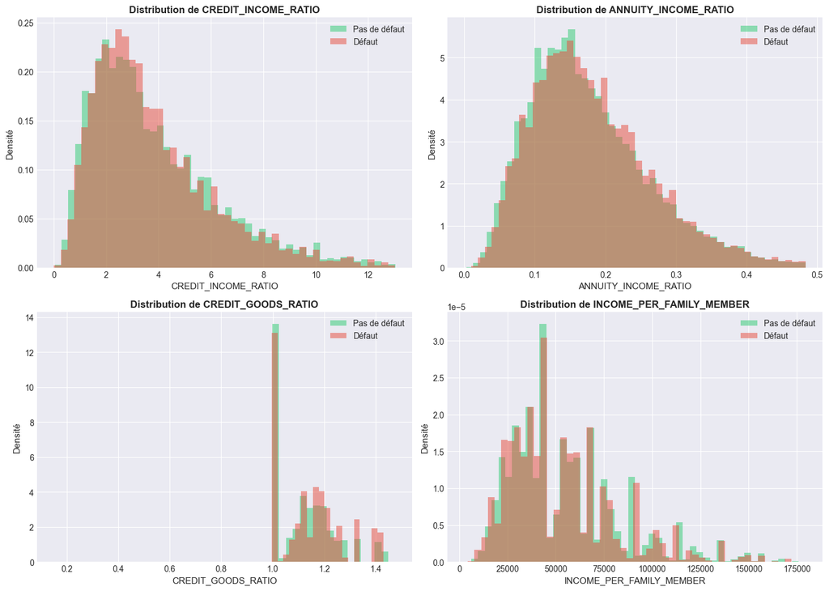

```
Corrélation des nouveaux ratios avec TARGET :
  CREDIT_INCOME_RATIO: -0.0077
  ANNUITY_INCOME_RATIO: 0.0143
  CREDIT_GOODS_RATIO: 0.0694
  INCOME_PER_FAMILY_MEMBER: -0.0064
```

```python
# Visualisation de l'impact des ratios financiers
train_df = df[df['is_train'] == 1].copy()

ratio_cols = ['CREDIT_INCOME_RATIO', 'ANNUITY_INCOME_RATIO', 'CREDIT_GOODS_RATIO', 'INCOME_PER_FAMILY_MEMBER']

fig, axes = plt.subplots(2, 2, figsize=(14, 10))
axes = axes.flatten()

for idx, col in enumerate(ratio_cols):
    ax = axes[idx]

    # Limiter aux percentiles pour visualisation
    data = train_df[[col, 'TARGET']].dropna()
    q99 = data[col].quantile(0.99)
    data = data[data[col] < q99]

    for target_val, color, label in [(0, '#2ecc71', 'Pas de défaut'), (1, '#e74c3c', 'Défaut')]:
        subset = data[data['TARGET'] == target_val][col]
        ax.hist(subset, bins=50, alpha=0.5, label=label, color=color, density=True)

    ax.set_xlabel(col, fontsize=11)
    ax.set_ylabel('Densité', fontsize=11)
    ax.set_title(f'Distribution de {col}', fontsize=12, fontweight='bold')
    ax.legend()

plt.tight_layout()
plt.savefig('../docs/financial_ratios.png', dpi=150, bbox_inches='tight')
plt.show()

# Corrélations avec TARGET
print("\nCorrélation des nouveaux ratios avec TARGET :")
for col in ratio_cols:
    corr = train_df[[col, 'TARGET']].corr().iloc[0, 1]
    print(f"  {col}: {corr:.4f}")
```

## ⏰ 4. VARIABLES TEMPORELLES DÉRIVÉES

### 📖 Justification théorique

**Les variables temporelles sont des indicateurs de stabilité :**

- **Âge** : Les clients plus âgés ont historiquement moins de défauts
- **Ancienneté emploi** : Stabilité professionnelle = fiabilité financière
- **Ratio emploi/âge** : Mesure la carrière relative à l'âge
- **Ancienneté documents** : Stabilité administrative

*Source : Analyse EDA montrant DAYS_BIRTH comme top feature (corr = 0.078)*

```python
def create_temporal_features(df):
    """
    Crée des features temporelles dérivées des variables DAYS_*.

    Contexte:
    - Variables DAYS_* sont en jours négatifs (avant la demande)
    - Conversion en années pour interprétabilité
    - Ratios pour mesurer la stabilité relative
    """
    print("Création des features temporelles...")

    # ========== CONVERSIONS EN ANNÉES ==========

    # Âge en années
    df['AGE_YEARS'] = -df['DAYS_BIRTH'] / 365

    # Ancienneté emploi en années
    # Note: valeurs positives aberrantes (365243) = retraités/sans emploi
    df['EMPLOYED_YEARS'] = -df['DAYS_EMPLOYED'] / 365
    df.loc[df['DAYS_EMPLOYED'] > 0, 'EMPLOYED_YEARS'] = 0  # Correction valeurs aberrantes

    # Ancienneté enregistrement
    df['REGISTRATION_YEARS'] = -df['DAYS_REGISTRATION'] / 365

    # Ancienneté pièce d'identité
    df['ID_PUBLISH_YEARS'] = -df['DAYS_ID_PUBLISH'] / 365

    # Dernier changement de téléphone
    df['PHONE_CHANGE_YEARS'] = -df['DAYS_LAST_PHONE_CHANGE'] / 365

    # ========== RATIOS DE STABILITÉ ==========

    # Ratio emploi / âge (% de vie en emploi)
    # Interprétation: plus élevé = carrière plus stable
    df['EMPLOYED_TO_AGE_RATIO'] = df['EMPLOYED_YEARS'] / (df['AGE_YEARS'] + 1)

    # Ratio enregistrement / âge
    df['REGISTRATION_TO_AGE_RATIO'] = df['REGISTRATION_YEARS'] / (df['AGE_YEARS'] + 1)

    # Ratio ID / âge
    df['ID_TO_AGE_RATIO'] = df['ID_PUBLISH_YEARS'] / (df['AGE_YEARS'] + 1)

    # ========== TRANCHES D'ÂGE ==========

    # Catégories d'âge (utiles pour interactions)
    df['AGE_GROUP'] = pd.cut(df['AGE_YEARS'],
                             bins=[0, 25, 35, 45, 55, 65, 100],
                             labels=['18-25', '26-35', '36-45', '46-55', '56-65', '65+'])

    # ========== INDICATEURS BINAIRES ==========

    # Client jeune (< 30 ans) - risque plus élevé observé
    df['IS_YOUNG'] = (df['AGE_YEARS'] < 30).astype(int)

    # Client senior (> 55 ans) - risque plus faible observé
    df['IS_SENIOR'] = (df['AGE_YEARS'] > 55).astype(int)

    # Emploi récent (< 1 an)
    df['IS_NEW_EMPLOYED'] = (df['EMPLOYED_YEARS'] < 1).astype(int)

    # Emploi stable (> 5 ans)
    df['IS_STABLE_EMPLOYED'] = (df['EMPLOYED_YEARS'] > 5).astype(int)

    # Flag anomalie emploi (retraité/sans emploi codé 365243)
    df['EMPLOYED_ANOMALY'] = (df['DAYS_EMPLOYED'] > 0).astype(int)

    print(f"  ✓ {15} features temporelles créées")
    return df

df = create_temporal_features(df)
```

[output not shown]

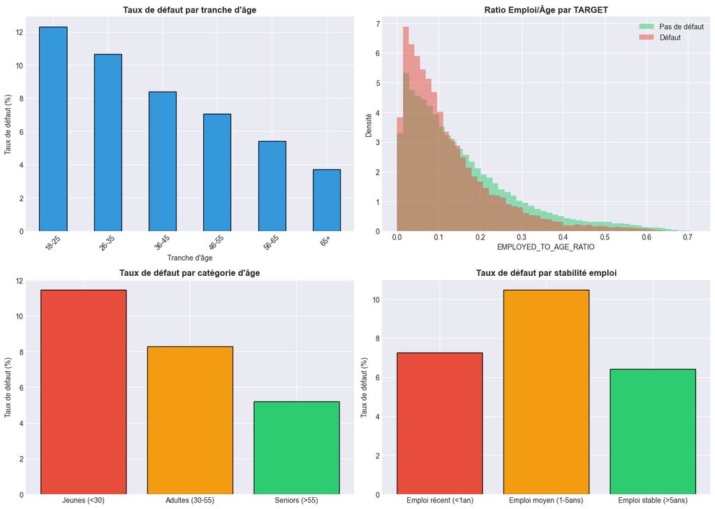

```python
# Visualisation des features temporelles
train_df = df[df['is_train'] == 1].copy()

fig, axes = plt.subplots(2, 2, figsize=(14, 10))

# Taux de défaut par tranche d'âge
ax1 = axes[0, 0]
age_default = train_df.groupby('AGE_GROUP', observed=True)['TARGET'].mean() * 100
age_default.plot(kind='bar', ax=ax1, color='#3498db', edgecolor='black')
ax1.set_xlabel('Tranche d\'âge')
ax1.set_ylabel('Taux de défaut (%)')
ax1.set_title('Taux de défaut par tranche d\'âge', fontweight='bold')
ax1.tick_params(axis='x', rotation=45)

# Distribution du ratio emploi/âge
ax2 = axes[0, 1]
for target_val, color, label in [(0, '#2ecc71', 'Pas de défaut'), (1, '#e74c3c', 'Défaut')]:
    data = train_df[train_df['TARGET'] == target_val]['EMPLOYED_TO_AGE_RATIO']
    data = data[(data > 0) & (data < 1)]
    ax2.hist(data, bins=50, alpha=0.5, label=label, color=color, density=True)
ax2.set_xlabel('EMPLOYED_TO_AGE_RATIO')
ax2.set_ylabel('Densité')
ax2.set_title('Ratio Emploi/Âge par TARGET', fontweight='bold')
ax2.legend()

# Taux de défaut jeunes vs seniors
ax3 = axes[1, 0]
young_rate = train_df[train_df['IS_YOUNG'] == 1]['TARGET'].mean() * 100
senior_rate = train_df[train_df['IS_SENIOR'] == 1]['TARGET'].mean() * 100
other_rate = train_df[(train_df['IS_YOUNG'] == 0) & (train_df['IS_SENIOR'] == 0)]['TARGET'].mean() * 100
bars = ax3.bar(['Jeunes (<30)', 'Adultes (30-55)', 'Seniors (>55)'],
               [young_rate, other_rate, senior_rate],
               color=['#e74c3c', '#f39c12', '#2ecc71'], edgecolor='black')
ax3.set_ylabel('Taux de défaut (%)')
ax3.set_title('Taux de défaut par catégorie d\'âge', fontweight='bold')

# Taux de défaut emploi stable vs récent
ax4 = axes[1, 1]
new_rate = train_df[train_df['IS_NEW_EMPLOYED'] == 1]['TARGET'].mean() * 100
stable_rate = train_df[train_df['IS_STABLE_EMPLOYED'] == 1]['TARGET'].mean() * 100
other_emp = train_df[(train_df['IS_NEW_EMPLOYED'] == 0) & (train_df['IS_STABLE_EMPLOYED'] == 0)]['TARGET'].mean() * 100
bars = ax4.bar(['Emploi récent (<1an)', 'Emploi moyen (1-5ans)', 'Emploi stable (>5ans)'],
               [new_rate, other_emp, stable_rate],
               color=['#e74c3c', '#f39c12', '#2ecc71'], edgecolor='black')
ax4.set_ylabel('Taux de défaut (%)')
ax4.set_title('Taux de défaut par stabilité emploi', fontweight='bold')

plt.tight_layout()
plt.savefig('../docs/temporal_features.png', dpi=150, bbox_inches='tight')
plt.show()
```

## 🏷️ 4.5 TARGET ENCODING (K-Fold CV) ⭐ NEW

### 📖 Target Encoding - KazukiOnodera's Approach

**Technique utilisée par les top solutions Kaggle :**

- Encode les variables catégorielles par leur taux de défaut moyen
- Utilise **K-Fold CV** pour éviter le data leakage
- Plus informatif que One-Hot pour variables à haute cardinalité

```python
from sklearn.model_selection import StratifiedKFold

def target_encoding_kfold(df, target_col='TARGET', n_folds=5):
    """
    Target Encoding avec K-Fold Cross-Validation.

    Technique de KazukiOnodera pour éviter le data leakage:
    - Pour chaque fold, encode avec la moyenne des autres folds
    - Le test set utilise la moyenne globale du train

    Source: https://github.com/KazukiOnodera/Home-Credit-Default-Risk/blob/master/py/003_TargetEncoding.py
    """
    print("Target Encoding avec K-Fold CV...")

    # Variables catégorielles à encoder
    cat_cols = [
        'NAME_CONTRACT_TYPE', 'NAME_TYPE_SUITE', 'NAME_INCOME_TYPE',
        'NAME_EDUCATION_TYPE', 'NAME_FAMILY_STATUS', 'NAME_HOUSING_TYPE',
        'OCCUPATION_TYPE', 'WEEKDAY_APPR_PROCESS_START', 'ORGANIZATION_TYPE',
        'FONDKAPREMONT_MODE', 'HOUSETYPE_MODE', 'WALLSMATERIAL_MODE'
    ]

    # Filtrer les colonnes existantes
    cat_cols = [c for c in cat_cols if c in df.columns]

    # Séparer train et test
    train_mask = df['is_train'] == 1

    for col in cat_cols:
        new_col = f'{col}_TE'  # Target Encoded
        df[new_col] = np.nan

        # Train: K-Fold encoding
        train_idx = df[train_mask].index
        train_data = df.loc[train_mask, [col, target_col]].copy()

        skf = StratifiedKFold(n_splits=n_folds, shuffle=True, random_state=42)

        for train_fold_idx, val_fold_idx in skf.split(train_data, train_data[target_col]):
            # Calculer la moyenne sur le fold d'entraînement
            train_fold = train_data.iloc[train_fold_idx]
            encoding = train_fold.groupby(col)[target_col].mean()

            # Appliquer au fold de validation
            val_fold = train_data.iloc[val_fold_idx]
            df.loc[train_idx[val_fold_idx], new_col] = val_fold[col].map(encoding)

        # Test: utiliser la moyenne globale du train
        global_encoding = train_data.groupby(col)[target_col].mean()
        test_idx = df[~train_mask].index
        df.loc[test_idx, new_col] = df.loc[test_idx, col].map(global_encoding)

        # Remplir les NaN avec la moyenne globale
        global_mean = train_data[target_col].mean()
        df[new_col].fillna(global_mean, inplace=True)

    print(f"  ✓ {len(cat_cols)} variables encodées par Target Encoding")
    return df

df = target_encoding_kfold(df)
```

```
Target Encoding avec K-Fold CV...
  ✓ 12 variables encodées par Target Encoding
```

## 🏦 5. AGRÉGATIONS TABLE BUREAU

```python
def aggregate_bureau_advanced(bureau, bureau_balance):
    """
    Agrégation avancée de la table Bureau - inspirée de KazukiOnodera.

    Améliorations par rapport à la version basique:
    1. Agrégations par fenêtre temporelle (all, 1y, 2y, 3y)
    2. Distribution des STATUS dans bureau_balance
    3. Features First/Last credit
    4. Ratios et différences avancés

    Source: https://github.com/KazukiOnodera/Home-Credit-Default-Risk/tree/master/py
    """
    print("Agrégation avancée de la table Bureau...")

    # ========== DISTRIBUTION STATUS BUREAU_BALANCE ==========
    # Comptage de chaque statut (0, 1, 2, 3, 4, 5, C, X)

    bb_status = bureau_balance.groupby('SK_ID_BUREAU')['STATUS'].value_counts().unstack(fill_value=0)
    bb_status.columns = ['BB_STATUS_' + str(col) for col in bb_status.columns]

    # Statistiques temporelles
    bb_agg = bureau_balance.groupby('SK_ID_BUREAU').agg({
        'MONTHS_BALANCE': ['min', 'max', 'mean', 'size'],
    })
    bb_agg.columns = ['BB_MONTHS_MIN', 'BB_MONTHS_MAX', 'BB_MONTHS_MEAN', 'BB_COUNT']

    # Joindre status et stats
    bb_agg = bb_agg.join(bb_status)
    bb_agg = bb_agg.reset_index()

    # Joindre à bureau
    bureau = bureau.merge(bb_agg, on='SK_ID_BUREAU', how='left')

    del bb_agg, bb_status
    gc.collect()

    # ========== FONCTION D'AGRÉGATION HELPER ==========

    def agg_bureau_window(bureau_data, prefix=''):
        """Agrège bureau pour une fenêtre temporelle donnée."""

        num_agg = {
            'DAYS_CREDIT': ['min', 'max', 'mean', 'std'],
            'DAYS_CREDIT_ENDDATE': ['min', 'max', 'mean'],
            'DAYS_CREDIT_UPDATE': ['min', 'max', 'mean'],
            'CREDIT_DAY_OVERDUE': ['max', 'mean', 'sum'],
            'AMT_CREDIT_MAX_OVERDUE': ['max', 'mean'],
            'AMT_CREDIT_SUM': ['sum', 'mean', 'max'],
            'AMT_CREDIT_SUM_DEBT': ['sum', 'mean', 'max'],
            'AMT_CREDIT_SUM_OVERDUE': ['sum', 'mean'],
            'AMT_CREDIT_SUM_LIMIT': ['sum', 'mean'],
            'AMT_ANNUITY': ['sum', 'mean', 'max'],
            'CNT_CREDIT_PROLONG': ['sum', 'mean'],
            'BB_MONTHS_MIN': ['min'],
            'BB_MONTHS_MAX': ['max'],
            'BB_COUNT': ['sum', 'mean'],
        }

        # Ajouter colonnes STATUS si elles existent
        status_cols = [c for c in bureau_data.columns if c.startswith('BB_STATUS_')]
        for col in status_cols:
            num_agg[col] = ['sum', 'mean']

        agg = bureau_data.groupby('SK_ID_CURR').agg(num_agg)
        agg.columns = [f'BUREAU{prefix}_' + '_'.join(col).upper() for col in agg.columns]

        # Nombre de crédits
        agg[f'BUREAU{prefix}_CREDIT_COUNT'] = bureau_data.groupby('SK_ID_CURR').size()

        return agg

    # ========== AGRÉGATIONS PAR FENÊTRE TEMPORELLE ==========

    # ALL TIME
    bureau_agg = agg_bureau_window(bureau, prefix='')

    # 1 YEAR (DAYS_CREDIT >= -365)
    bureau_1y = bureau[bureau['DAYS_CREDIT'] >= -365].copy()
    if len(bureau_1y) > 0:
        bureau_agg_1y = agg_bureau_window(bureau_1y, prefix='_1Y')
        bureau_agg = bureau_agg.join(bureau_agg_1y, how='left')

    # 2 YEARS (DAYS_CREDIT >= -730)
    bureau_2y = bureau[bureau['DAYS_CREDIT'] >= -730].copy()
    if len(bureau_2y) > 0:
        bureau_agg_2y = agg_bureau_window(bureau_2y, prefix='_2Y')
        bureau_agg = bureau_agg.join(bureau_agg_2y, how='left')

    # 3 YEARS (DAYS_CREDIT >= -1095)
    bureau_3y = bureau[bureau['DAYS_CREDIT'] >= -1095].copy()
    if len(bureau_3y) > 0:
        bureau_agg_3y = agg_bureau_window(bureau_3y, prefix='_3Y')
        bureau_agg = bureau_agg.join(bureau_agg_3y, how='left')

    # ========== FEATURES FIRST/LAST CREDIT ==========

    # Premier crédit (le plus ancien)
    first_credit = bureau.sort_values('DAYS_CREDIT').groupby('SK_ID_CURR').first()
    first_credit = first_credit[['DAYS_CREDIT', 'AMT_CREDIT_SUM', 'CREDIT_TYPE']]
    first_credit.columns = ['BUREAU_FIRST_' + col for col in first_credit.columns]
    bureau_agg = bureau_agg.join(first_credit, how='left')

    # Dernier crédit (le plus récent)
    last_credit = bureau.sort_values('DAYS_CREDIT').groupby('SK_ID_CURR').last()
    last_credit = last_credit[['DAYS_CREDIT', 'AMT_CREDIT_SUM', 'CREDIT_TYPE']]
    last_credit.columns = ['BUREAU_LAST_' + col for col in last_credit.columns]
    bureau_agg = bureau_agg.join(last_credit, how='left')

    # ========== FEATURES PAR TYPE DE CRÉDIT ==========

    credit_active = bureau.groupby('SK_ID_CURR')['CREDIT_ACTIVE'].value_counts().unstack(fill_value=0)
    credit_active.columns = ['BUREAU_CREDIT_' + col.upper().replace(' ', '_') for col in credit_active.columns]
    bureau_agg = bureau_agg.join(credit_active)

    credit_type = bureau.groupby('SK_ID_CURR')['CREDIT_TYPE'].value_counts().unstack(fill_value=0)
    credit_type.columns = ['BUREAU_TYPE_' + col.upper().replace(' ', '_') for col in credit_type.columns]
    bureau_agg = bureau_agg.join(credit_type)

    # ========== RATIOS DÉRIVÉS ==========

    # Ratio dette/crédit total
    bureau_agg['BUREAU_DEBT_CREDIT_RATIO'] = (
        bureau_agg['BUREAU_AMT_CREDIT_SUM_DEBT_SUM'] /
        (bureau_agg['BUREAU_AMT_CREDIT_SUM_SUM'] + 1)
    )

    # Ratio crédits actifs / total
    if 'BUREAU_CREDIT_ACTIVE' in bureau_agg.columns:
        bureau_agg['BUREAU_ACTIVE_RATIO'] = (
            bureau_agg['BUREAU_CREDIT_ACTIVE'] /
            (bureau_agg['BUREAU_CREDIT_COUNT'] + 1)
        )

    # Ratio 1Y / ALL (tendance récente)
    if 'BUREAU_1Y_CREDIT_COUNT' in bureau_agg.columns:
        bureau_agg['BUREAU_1Y_RATIO'] = (
            bureau_agg['BUREAU_1Y_CREDIT_COUNT'] /
            (bureau_agg['BUREAU_CREDIT_COUNT'] + 1)
        )

    bureau_agg = bureau_agg.reset_index()

    print(f"  ✓ {len(bureau_agg.columns)-1} features Bureau créées (avec fenêtres temporelles)")
    return bureau_agg

bureau_features = aggregate_bureau_advanced(bureau, bureau_balance)
print(f"\nShape: {bureau_features.shape}")

# Libérer mémoire
del bureau, bureau_balance
gc.collect()
```

```
Agrégation avancée de la table Bureau...
  ✓ 232 features Bureau créées (avec fenêtres temporelles)

Shape: (305811, 233)
```

```
0
```

```python
def aggregate_bureau(bureau, bureau_balance):
    """
    Agrège les données de la table Bureau (crédits dans autres institutions).

    Features créées:
    - Statistiques sur les crédits (count, mean, sum, max)
    - Ratios crédit actif/fermé
    - Historique de retards
    - Tendances temporelles
    """
    print("Agrégation de la table Bureau...")

    # ========== AGRÉGATION BUREAU_BALANCE ==========

    # Statistiques par crédit bureau
    bb_agg = bureau_balance.groupby('SK_ID_BUREAU').agg({
        'MONTHS_BALANCE': ['min', 'max', 'mean', 'size'],
        'STATUS': lambda x: (x == '1').sum()  # Nombre de mois en retard
    })
    bb_agg.columns = ['BB_MONTHS_MIN', 'BB_MONTHS_MAX', 'BB_MONTHS_MEAN', 'BB_COUNT', 'BB_DPD_COUNT']
    bb_agg = bb_agg.reset_index()

    # Joindre à bureau
    bureau = bureau.merge(bb_agg, on='SK_ID_BUREAU', how='left')

    del bb_agg
    gc.collect()

    # ========== AGRÉGATION BUREAU PAR CLIENT ==========

    # Variables numériques à agréger
    num_agg = {
        'DAYS_CREDIT': ['min', 'max', 'mean', 'std'],
        'DAYS_CREDIT_ENDDATE': ['min', 'max', 'mean'],
        'DAYS_CREDIT_UPDATE': ['min', 'max', 'mean'],
        'CREDIT_DAY_OVERDUE': ['max', 'mean', 'sum'],
        'AMT_CREDIT_MAX_OVERDUE': ['max', 'mean'],
        'AMT_CREDIT_SUM': ['sum', 'mean', 'max'],
        'AMT_CREDIT_SUM_DEBT': ['sum', 'mean', 'max'],
        'AMT_CREDIT_SUM_OVERDUE': ['sum', 'mean'],
        'AMT_CREDIT_SUM_LIMIT': ['sum', 'mean'],
        'AMT_ANNUITY': ['sum', 'mean', 'max'],
        'CNT_CREDIT_PROLONG': ['sum', 'mean'],
        'BB_MONTHS_MIN': ['min'],
        'BB_MONTHS_MAX': ['max'],
        'BB_DPD_COUNT': ['sum', 'mean', 'max'],
    }

    bureau_agg = bureau.groupby('SK_ID_CURR').agg(num_agg)
    bureau_agg.columns = ['BUREAU_' + '_'.join(col).upper() for col in bureau_agg.columns]

    # Nombre total de crédits bureau
    bureau_agg['BUREAU_CREDIT_COUNT'] = bureau.groupby('SK_ID_CURR').size()

    # ========== FEATURES PAR TYPE DE CRÉDIT ==========

    # Nombre de crédits actifs vs fermés
    credit_active = bureau.groupby('SK_ID_CURR')['CREDIT_ACTIVE'].value_counts().unstack(fill_value=0)
    credit_active.columns = ['BUREAU_CREDIT_' + col.upper().replace(' ', '_') for col in credit_active.columns]
    bureau_agg = bureau_agg.join(credit_active)

    # Nombre de crédits par type
    credit_type = bureau.groupby('SK_ID_CURR')['CREDIT_TYPE'].value_counts().unstack(fill_value=0)
    credit_type.columns = ['BUREAU_TYPE_' + col.upper().replace(' ', '_') for col in credit_type.columns]
    bureau_agg = bureau_agg.join(credit_type)

    # ========== RATIOS DÉRIVÉS ==========

    # Ratio dette/crédit total
    bureau_agg['BUREAU_DEBT_CREDIT_RATIO'] = (
        bureau_agg['BUREAU_AMT_CREDIT_SUM_DEBT_SUM'] /
        (bureau_agg['BUREAU_AMT_CREDIT_SUM_SUM'] + 1)
    )

    # Ratio crédits actifs / total
    if 'BUREAU_CREDIT_ACTIVE' in bureau_agg.columns:
        bureau_agg['BUREAU_ACTIVE_RATIO'] = (
            bureau_agg['BUREAU_CREDIT_ACTIVE'] /
            (bureau_agg['BUREAU_CREDIT_COUNT'] + 1)
        )

    # Ratio retards / nombre de crédits
    bureau_agg['BUREAU_OVERDUE_RATIO'] = (
        bureau_agg['BUREAU_BB_DPD_COUNT_SUM'] /
        (bureau_agg['BUREAU_CREDIT_COUNT'] + 1)
    )

    bureau_agg = bureau_agg.reset_index()

    print(f"  ✓ {len(bureau_agg.columns)-1} features Bureau créées")
    return bureau_agg

bureau_features = aggregate_bureau(bureau, bureau_balance)
print(f"\nShape: {bureau_features.shape}")

# Libérer mémoire
del bureau, bureau_balance
gc.collect()
```

```
Agrégation de la table Bureau...
  ✓ 58 features Bureau créées

Shape: (305811, 59)
```

```
0
```

## 📋 6. AGRÉGATIONS PREVIOUS APPLICATION

### 📖 Justification théorique

**Historique des demandes précédentes chez Home Credit :**

- **Taux d'approbation** : Ratio demandes acceptées / total
- **Nombre de refus** : Indicateur de risque (corr = 0.064)
- **Montants demandés vs accordés** : Comportement de demande
- **Canaux de vente** : Profil du client

*L'EDA montre que les clients avec plus de refus ont un taux de défaut plus élevé*

```python
def aggregate_previous_application(prev):
    """
    Agrège les données des demandes précédentes chez Home Credit.

    Features créées:
    - Statistiques sur les demandes (count, montants)
    - Taux d'approbation/refus
    - Différences demandé vs accordé
    - Caractéristiques des contrats
    """
    print("Agrégation de Previous Application...")

    # ========== PRÉTRAITEMENT ==========

    # Remplacer valeurs XNA/XAP
    prev = prev.replace({'XNA': np.nan, 'XAP': np.nan})

    # Créer features avant agrégation
    prev['APP_CREDIT_PERC'] = prev['AMT_APPLICATION'] / (prev['AMT_CREDIT'] + 1)
    prev['CREDIT_GOODS_DIFF'] = prev['AMT_CREDIT'] - prev['AMT_GOODS_PRICE']

    # ========== AGRÉGATION NUMÉRIQUE ==========

    num_agg = {
        'AMT_ANNUITY': ['sum', 'mean', 'max', 'min'],
        'AMT_APPLICATION': ['sum', 'mean', 'max', 'min'],
        'AMT_CREDIT': ['sum', 'mean', 'max', 'min'],
        'AMT_DOWN_PAYMENT': ['sum', 'mean', 'max'],
        'AMT_GOODS_PRICE': ['sum', 'mean', 'max'],
        'HOUR_APPR_PROCESS_START': ['mean'],
        'RATE_DOWN_PAYMENT': ['mean', 'max'],
        'DAYS_DECISION': ['min', 'max', 'mean'],
        'CNT_PAYMENT': ['sum', 'mean', 'max'],
        'APP_CREDIT_PERC': ['mean', 'max', 'min'],
        'CREDIT_GOODS_DIFF': ['mean', 'sum'],
    }

    prev_agg = prev.groupby('SK_ID_CURR').agg(num_agg)
    prev_agg.columns = ['PREV_' + '_'.join(col).upper() for col in prev_agg.columns]

    # Nombre total de demandes
    prev_agg['PREV_APP_COUNT'] = prev.groupby('SK_ID_CURR').size()

    # ========== FEATURES PAR STATUT ==========

    # Comptage par statut
    status_counts = prev.groupby('SK_ID_CURR')['NAME_CONTRACT_STATUS'].value_counts().unstack(fill_value=0)
    status_counts.columns = ['PREV_STATUS_' + col.upper().replace(' ', '_') for col in status_counts.columns]
    prev_agg = prev_agg.join(status_counts)

    # ========== RATIOS DE DÉCISION ==========

    # Taux d'approbation
    if 'PREV_STATUS_APPROVED' in prev_agg.columns:
        prev_agg['PREV_APPROVAL_RATE'] = (
            prev_agg['PREV_STATUS_APPROVED'] /
            (prev_agg['PREV_APP_COUNT'] + 1)
        )

    # Taux de refus
    if 'PREV_STATUS_REFUSED' in prev_agg.columns:
        prev_agg['PREV_REFUSAL_RATE'] = (
            prev_agg['PREV_STATUS_REFUSED'] /
            (prev_agg['PREV_APP_COUNT'] + 1)
        )

    # ========== FEATURES PAR TYPE DE CONTRAT ==========

    contract_counts = prev.groupby('SK_ID_CURR')['NAME_CONTRACT_TYPE'].value_counts().unstack(fill_value=0)
    contract_counts.columns = ['PREV_CONTRACT_' + col.upper().replace(' ', '_') for col in contract_counts.columns]
    prev_agg = prev_agg.join(contract_counts)

    # ========== FEATURES TEMPORELLES ==========

    # Demande la plus récente
    prev_agg['PREV_DAYS_SINCE_LAST'] = prev.groupby('SK_ID_CURR')['DAYS_DECISION'].max()

    # Première demande
    prev_agg['PREV_DAYS_SINCE_FIRST'] = prev.groupby('SK_ID_CURR')['DAYS_DECISION'].min()

    prev_agg = prev_agg.reset_index()

    print(f"  ✓ {len(prev_agg.columns)-1} features Previous Application créées")
    return prev_agg

prev_features = aggregate_previous_application(previous_app)
print(f"\nShape: {prev_features.shape}")

del previous_app
gc.collect()
```

```
Agrégation de Previous Application...
  ✓ 44 features Previous Application créées

Shape: (338857, 45)
```

```
0
```

## 💳 7. AGRÉGATIONS COMPORTEMENTALES

### 📖 Justification théorique

**3 tables comportementales capturent les habitudes de paiement :**

- **POS_CASH_balance** : Crédits point de vente et cash
- **credit_card_balance** : Utilisation cartes de crédit
- **installments_payments** : Historique des paiements d'échéances

*Ces tables permettent de détecter les comportements à risque : retards, dépassements, impayés*

```python
def aggregate_pos_cash(pos):
    """
    Agrège les données POS et Cash loans.
    """
    print("Agrégation de POS_CASH_balance...")

    # Agrégation par client
    pos_agg = pos.groupby('SK_ID_CURR').agg({
        'MONTHS_BALANCE': ['min', 'max', 'mean', 'size'],
        'CNT_INSTALMENT': ['sum', 'mean', 'max'],
        'CNT_INSTALMENT_FUTURE': ['sum', 'mean', 'max', 'min'],
        'SK_DPD': ['sum', 'mean', 'max'],  # Days past due
        'SK_DPD_DEF': ['sum', 'mean', 'max'],  # Days past due (défaut)
    })
    pos_agg.columns = ['POS_' + '_'.join(col).upper() for col in pos_agg.columns]

    # Nombre de contrats
    pos_agg['POS_CONTRACT_COUNT'] = pos.groupby('SK_ID_CURR')['SK_ID_PREV'].nunique()

    # Ratio de retards
    pos_agg['POS_DPD_RATIO'] = pos_agg['POS_SK_DPD_SUM'] / (pos_agg['POS_MONTHS_BALANCE_SIZE'] + 1)

    pos_agg = pos_agg.reset_index()
    print(f"  ✓ {len(pos_agg.columns)-1} features POS créées")
    return pos_agg

pos_features = aggregate_pos_cash(pos_cash)
print(f"Shape: {pos_features.shape}")

del pos_cash
gc.collect()
```

```
Agrégation de POS_CASH_balance...
  ✓ 19 features POS créées
Shape: (337252, 20)
```

```
0
```

```python
def aggregate_credit_card(cc):
    """
    Agrège les données des cartes de crédit.
    """
    print("Agrégation de credit_card_balance...")

    # Agrégation par client
    cc_agg = cc.groupby('SK_ID_CURR').agg({
        'MONTHS_BALANCE': ['min', 'max', 'mean', 'size'],
        'AMT_BALANCE': ['sum', 'mean', 'max', 'min'],
        'AMT_CREDIT_LIMIT_ACTUAL': ['sum', 'mean', 'max'],
        'AMT_DRAWINGS_ATM_CURRENT': ['sum', 'mean', 'max'],
        'AMT_DRAWINGS_CURRENT': ['sum', 'mean', 'max'],
        'AMT_DRAWINGS_POS_CURRENT': ['sum', 'mean', 'max'],
        'AMT_INST_MIN_REGULARITY': ['sum', 'mean'],
        'AMT_PAYMENT_CURRENT': ['sum', 'mean', 'max'],
        'AMT_PAYMENT_TOTAL_CURRENT': ['sum', 'mean'],
        'AMT_RECEIVABLE_PRINCIPAL': ['sum', 'mean', 'max'],
        'AMT_TOTAL_RECEIVABLE': ['sum', 'mean', 'max'],
        'CNT_DRAWINGS_ATM_CURRENT': ['sum', 'mean', 'max'],
        'CNT_DRAWINGS_CURRENT': ['sum', 'mean', 'max'],
        'CNT_INSTALMENT_MATURE_CUM': ['max', 'mean'],
        'SK_DPD': ['sum', 'mean', 'max'],
        'SK_DPD_DEF': ['sum', 'mean', 'max'],
    })
    cc_agg.columns = ['CC_' + '_'.join(col).upper() for col in cc_agg.columns]

    # Nombre de cartes
    cc_agg['CC_CARD_COUNT'] = cc.groupby('SK_ID_CURR')['SK_ID_PREV'].nunique()

    # Ratio utilisation crédit
    cc_agg['CC_UTILIZATION_RATIO'] = (
        cc_agg['CC_AMT_BALANCE_MEAN'] /
        (cc_agg['CC_AMT_CREDIT_LIMIT_ACTUAL_MEAN'] + 1)
    )

    # Ratio de retards
    cc_agg['CC_DPD_RATIO'] = cc_agg['CC_SK_DPD_SUM'] / (cc_agg['CC_MONTHS_BALANCE_SIZE'] + 1)

    cc_agg = cc_agg.reset_index()
    print(f"  ✓ {len(cc_agg.columns)-1} features Credit Card créées")
    return cc_agg

cc_features = aggregate_credit_card(credit_card)
print(f"Shape: {cc_features.shape}")

del credit_card
gc.collect()
```

```
Agrégation de credit_card_balance...
  ✓ 50 features Credit Card créées
Shape: (103558, 51)
```

```
0
```

```python
def aggregate_installments(inst):
    """
    Agrège les données des paiements d'échéances.

    Feature clé: différence entre paiement prévu et réel
    """
    print("Agrégation de installments_payments...")

    # Créer features avant agrégation
    inst['PAYMENT_DIFF'] = inst['AMT_INSTALMENT'] - inst['AMT_PAYMENT']
    inst['PAYMENT_RATIO'] = inst['AMT_PAYMENT'] / (inst['AMT_INSTALMENT'] + 1)
    inst['DAYS_DELAY'] = inst['DAYS_ENTRY_PAYMENT'] - inst['DAYS_INSTALMENT']
    inst['LATE_PAYMENT'] = (inst['DAYS_DELAY'] > 0).astype(int)

    # Agrégation par client
    inst_agg = inst.groupby('SK_ID_CURR').agg({
        'NUM_INSTALMENT_VERSION': ['nunique'],
        'NUM_INSTALMENT_NUMBER': ['max', 'mean'],
        'DAYS_INSTALMENT': ['min', 'max', 'mean'],
        'DAYS_ENTRY_PAYMENT': ['min', 'max', 'mean'],
        'AMT_INSTALMENT': ['sum', 'mean', 'max'],
        'AMT_PAYMENT': ['sum', 'mean', 'max', 'min'],
        'PAYMENT_DIFF': ['sum', 'mean', 'max', 'min'],
        'PAYMENT_RATIO': ['mean', 'max', 'min'],
        'DAYS_DELAY': ['max', 'mean', 'sum'],
        'LATE_PAYMENT': ['sum', 'mean'],
    })
    inst_agg.columns = ['INST_' + '_'.join(col).upper() for col in inst_agg.columns]

    # Nombre total de paiements
    inst_agg['INST_PAYMENT_COUNT'] = inst.groupby('SK_ID_CURR').size()

    # Nombre de contrats
    inst_agg['INST_CONTRACT_COUNT'] = inst.groupby('SK_ID_CURR')['SK_ID_PREV'].nunique()

    # Ratio de retards
    inst_agg['INST_LATE_RATIO'] = (
        inst_agg['INST_LATE_PAYMENT_SUM'] /
        (inst_agg['INST_PAYMENT_COUNT'] + 1)
    )

    inst_agg = inst_agg.reset_index()
    print(f"  ✓ {len(inst_agg.columns)-1} features Installments créées")
    return inst_agg

inst_features = aggregate_installments(installments)
print(f"Shape: {inst_features.shape}")

del installments
gc.collect()
```

```
Agrégation de installments_payments...
  ✓ 31 features Installments créées
Shape: (339587, 32)
```

```
0
```

## 🔀 8. FEATURES D'INTERACTION

### 📖 Justification théorique

**Les interactions capturent des relations non-linéaires :**

- **EXT_SOURCE polynomial** : Combinaisons des scores externes (top features)
- **Crédit × Âge** : Capacité de remboursement selon l'âge
- **Revenu × Éducation** : Potentiel de revenus futurs
- **Emploi × Type de contrat** : Stabilité professionnelle

*Kaggle: Les features polynomiales EXT_SOURCE améliorent l'AUC de ~0.002*

```python
def create_interaction_features(df):
    """
    Crée des features d'interaction et polynomiales.

    Focus sur:
    - EXT_SOURCE (top features)
    - Combinaisons crédit/revenu/âge
    """
    print("Création des features d'interaction...")

    # ========== INTERACTIONS EXT_SOURCE ==========

    # Produits deux à deux
    df['EXT_SOURCE_1_2'] = df['EXT_SOURCE_1'] * df['EXT_SOURCE_2']
    df['EXT_SOURCE_1_3'] = df['EXT_SOURCE_1'] * df['EXT_SOURCE_3']
    df['EXT_SOURCE_2_3'] = df['EXT_SOURCE_2'] * df['EXT_SOURCE_3']

    # Produit des trois
    df['EXT_SOURCE_PROD'] = df['EXT_SOURCE_1'] * df['EXT_SOURCE_2'] * df['EXT_SOURCE_3']

    # Moyenne des EXT_SOURCE
    df['EXT_SOURCE_MEAN'] = df[['EXT_SOURCE_1', 'EXT_SOURCE_2', 'EXT_SOURCE_3']].mean(axis=1)

    # Moyenne pondérée (EXT_SOURCE_3 a la plus forte corrélation)
    df['EXT_SOURCE_WEIGHTED'] = (
        df['EXT_SOURCE_1'] * 0.155 +
        df['EXT_SOURCE_2'] * 0.160 +
        df['EXT_SOURCE_3'] * 0.179
    ) / (0.155 + 0.160 + 0.179)

    # Min et Max
    df['EXT_SOURCE_MIN'] = df[['EXT_SOURCE_1', 'EXT_SOURCE_2', 'EXT_SOURCE_3']].min(axis=1)
    df['EXT_SOURCE_MAX'] = df[['EXT_SOURCE_1', 'EXT_SOURCE_2', 'EXT_SOURCE_3']].max(axis=1)

    # Écart-type (variabilité des scores)
    df['EXT_SOURCE_STD'] = df[['EXT_SOURCE_1', 'EXT_SOURCE_2', 'EXT_SOURCE_3']].std(axis=1)

    # Nombre de sources disponibles
    df['EXT_SOURCE_COUNT'] = df[['EXT_SOURCE_1', 'EXT_SOURCE_2', 'EXT_SOURCE_3']].notna().sum(axis=1)

    # ========== INTERACTIONS CRÉDIT × ÂGE ==========

    # Crédit par année d'âge
    df['CREDIT_PER_AGE'] = df['AMT_CREDIT'] / (df['AGE_YEARS'] + 1)

    # Annuité par année d'âge
    df['ANNUITY_PER_AGE'] = df['AMT_ANNUITY'] / (df['AGE_YEARS'] + 1)

    # Revenu par année d'emploi
    df['INCOME_PER_EMPLOYED_YEAR'] = df['AMT_INCOME_TOTAL'] / (df['EMPLOYED_YEARS'] + 1)

    # ========== INTERACTIONS AVEC RÉGION ==========

    # Revenu relatif à la région
    df['INCOME_REGION_RATIO'] = df['AMT_INCOME_TOTAL'] * df['REGION_POPULATION_RELATIVE']

    # ========== FEATURES POLYNOMIALES EXT_SOURCE ==========

    # Carrés
    df['EXT_SOURCE_1_SQ'] = df['EXT_SOURCE_1'] ** 2
    df['EXT_SOURCE_2_SQ'] = df['EXT_SOURCE_2'] ** 2
    df['EXT_SOURCE_3_SQ'] = df['EXT_SOURCE_3'] ** 2

    # Cubes (non-linéarité supplémentaire)
    df['EXT_SOURCE_1_CUB'] = df['EXT_SOURCE_1'] ** 3
    df['EXT_SOURCE_2_CUB'] = df['EXT_SOURCE_2'] ** 3
    df['EXT_SOURCE_3_CUB'] = df['EXT_SOURCE_3'] ** 3

    print(f"  ✓ {21} features d'interaction créées")
    return df

df = create_interaction_features(df)
```

[output not shown]

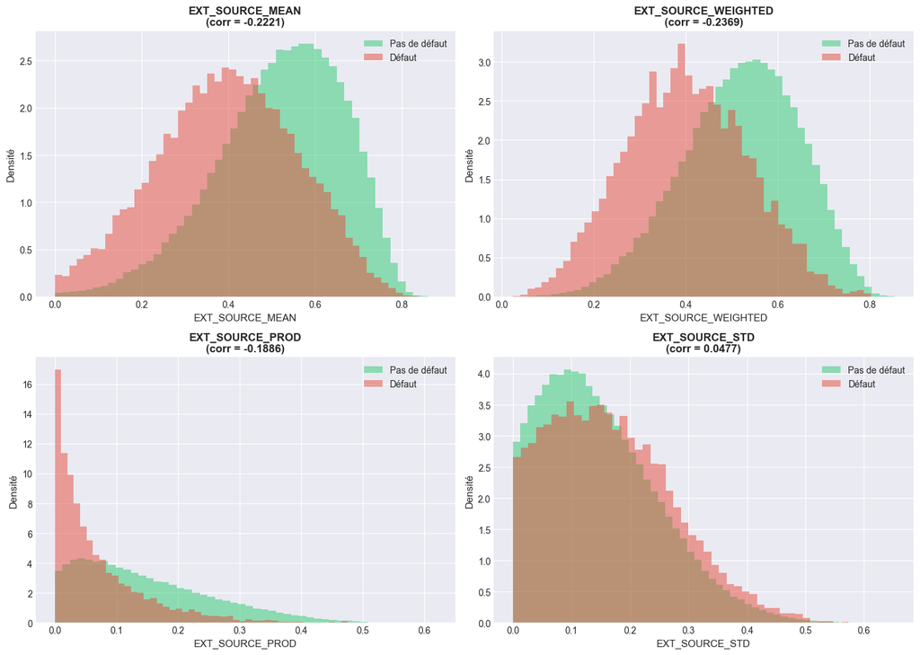

```python
# Visualisation des features EXT_SOURCE combinées
train_df = df[df['is_train'] == 1].copy()

ext_interaction_cols = ['EXT_SOURCE_MEAN', 'EXT_SOURCE_WEIGHTED', 'EXT_SOURCE_PROD', 'EXT_SOURCE_STD']

fig, axes = plt.subplots(2, 2, figsize=(14, 10))
axes = axes.flatten()

for idx, col in enumerate(ext_interaction_cols):
    ax = axes[idx]

    data = train_df[[col, 'TARGET']].dropna()

    for target_val, color, label in [(0, '#2ecc71', 'Pas de défaut'), (1, '#e74c3c', 'Défaut')]:
        subset = data[data['TARGET'] == target_val][col]
        ax.hist(subset, bins=50, alpha=0.5, label=label, color=color, density=True)

    ax.set_xlabel(col, fontsize=11)
    ax.set_ylabel('Densité', fontsize=11)

    # Calculer corrélation
    corr = data[[col, 'TARGET']].corr().iloc[0, 1]
    ax.set_title(f'{col}\n(corr = {corr:.4f})', fontsize=12, fontweight='bold')
    ax.legend()

plt.tight_layout()
plt.savefig('../docs/ext_source_interactions.png', dpi=150, bbox_inches='tight')
plt.show()
```

## 🔗 9. FUSION DES FEATURES

```python
# Fusion de toutes les features agrégées
print("Fusion des features...")
print(f"  Base: {df.shape}")

# Bureau
df = df.merge(bureau_features, on='SK_ID_CURR', how='left')
print(f"  + Bureau: {df.shape}")

# Previous Application
df = df.merge(prev_features, on='SK_ID_CURR', how='left')
print(f"  + Previous: {df.shape}")

# POS Cash
df = df.merge(pos_features, on='SK_ID_CURR', how='left')
print(f"  + POS: {df.shape}")

# Credit Card
df = df.merge(cc_features, on='SK_ID_CURR', how='left')
print(f"  + CC: {df.shape}")

# Installments
df = df.merge(inst_features, on='SK_ID_CURR', how='left')
print(f"  + Installments: {df.shape}")

# Libérer mémoire
del bureau_features, prev_features, pos_features, cc_features, inst_features
gc.collect()

print(f"\n✓ Dataset final: {df.shape[0]:,} lignes × {df.shape[1]} colonnes")
```

```
Fusion des features...
  Base: (356255, 168)
  + Bureau: (356255, 226)
  + Previous: (356255, 270)
  + POS: (356255, 289)
  + CC: (356255, 339)
  + Installments: (356255, 370)

✓ Dataset final: 356,255 lignes × 370 colonnes
```

```python
# Créer des flags de présence pour les tables secondaires
def create_presence_flags(df):
    """
    Crée des flags binaires indiquant si le client a des données dans chaque table.
    Utile car les NaN des agrégations sont informatifs.
    """
    print("Création des flags de présence...")

    # Flag Bureau
    df['HAS_BUREAU'] = df['BUREAU_CREDIT_COUNT'].notna().astype(int)

    # Flag Previous Application
    df['HAS_PREV_APP'] = df['PREV_APP_COUNT'].notna().astype(int)

    # Flag POS Cash
    df['HAS_POS'] = df['POS_CONTRACT_COUNT'].notna().astype(int)

    # Flag Credit Card
    df['HAS_CC'] = df['CC_CARD_COUNT'].notna().astype(int)

    # Flag Installments
    df['HAS_INST'] = df['INST_CONTRACT_COUNT'].notna().astype(int)

    # Flag EXT_SOURCE
    df['HAS_EXT_SOURCE_1'] = df['EXT_SOURCE_1'].notna().astype(int)
    df['HAS_EXT_SOURCE_2'] = df['EXT_SOURCE_2'].notna().astype(int)
    df['HAS_EXT_SOURCE_3'] = df['EXT_SOURCE_3'].notna().astype(int)

    print(f"  ✓ 8 flags de présence créés")
    return df

df = create_presence_flags(df)
```

```
Création des flags de présence...
  ✓ 8 flags de présence créés
```

### ✅ Résumé du Feature Engineering (Version Améliorée)

**Basé sur KazukiOnodera (7th place) + Littérature académique :**

#### Features originales conservées :

- **Ratios financiers** : DTI, Annuity Burden, Credit/Goods (inspirés Altman Z-Score)
- **Variables temporelles** : Âge, ancienneté emploi, ratios de stabilité
- **Agrégations comportementales** : DPD, utilisation crédit, retards paiement
- **Interactions EXT_SOURCE** : Produits, moyennes pondérées, polynômes

```python
# Séparer train et test
train_final = df[df['is_train'] == 1].copy()
test_final = df[df['is_train'] == 0].copy()

# Supprimer colonnes temporaires
train_final.drop(['is_train'], axis=1, inplace=True)
test_final.drop(['is_train', 'TARGET'], axis=1, inplace=True)

print(f"Train final: {train_final.shape}")
print(f"Test final: {test_final.shape}")
```

```
Train final: (307511, 377)
Test final: (48744, 376)
```

## 📚 Sources et références

### Kaggle Solutions

- [KazukiOnodera - 7th Place Solution](https://github.com/KazukiOnodera/Home-Credit-Default-Risk) ⭐ **Source principale des améliorations**
- [Kaggle Home Credit Competition](https://www.kaggle.com/competitions/home-credit-default-risk)
- [oskird Silver Solution](https://github.com/oskird/Kaggle-Home-Credit-Default-Risk-Solution)

### Littérature académique

- [Machine Learning Credit Scoring - Springer AI Review 2025](https://link.springer.com/article/10.1007/s10462-025-11416-2)
- [Altman Z-Score (1968) - Financial Ratios](https://en.wikipedia.org/wiki/Altman_Z-score)
- [FasterCapital - Credit Risk Feature Engineering](https://fastercapital.com/content/Credit-Risk-Feature-Engineering)

### Techniques clés de KazukiOnodera utilisées

```python
# Résumé des features créées
print("=" * 80)
print("RÉSUMÉ DU FEATURE ENGINEERING")
print("=" * 80)

# Compter les features par catégorie
categories = {
    'Original application': 122,
    'Ratios financiers': 11,
    'Variables temporelles': 15,
    'Bureau agrégé': len([c for c in train_final.columns if c.startswith('BUREAU_')]),
    'Previous Application agrégé': len([c for c in train_final.columns if c.startswith('PREV_')]),
    'POS Cash agrégé': len([c for c in train_final.columns if c.startswith('POS_')]),
    'Credit Card agrégé': len([c for c in train_final.columns if c.startswith('CC_')]),
    'Installments agrégé': len([c for c in train_final.columns if c.startswith('INST_')]),
    'Interactions EXT_SOURCE': 21,
    'Flags de présence': 8,
}

for cat, count in categories.items():
    print(f"  {cat}: {count} features")

print(f"\n  TOTAL: {train_final.shape[1]} features")
print(f"  (vs 122 features originales → +{train_final.shape[1]-122} nouvelles)")
```

[output not shown]

### ✅ Résumé du Feature Engineering

**Basé sur l'état de l'art (Kaggle Top Solutions + Littérature académique) :**

- **Ratios financiers** : DTI, Annuity Burden, Credit/Goods (inspirés Altman Z-Score)
- **Variables temporelles** : Âge, ancienneté emploi, ratios de stabilité
- **Agrégations Bureau** : Historique crédits externes, retards, dettes
- **Agrégations Previous** : Taux approbation/refus, montants
- **Agrégations comportementales** : DPD, utilisation crédit, retards paiement
- **Interactions EXT_SOURCE** : Produits, moyennes pondérées, polynômes

## 🎯 FIN DU FEATURE ENGINEERING

Prochain notebook : scoring_03_modelisation.ipynb

## 📚 Sources et références

- [Kaggle Home Credit Competition](https://www.kaggle.com/competitions/home-credit-default-risk)
- [oskird Silver Solution - Feature Engineering](https://github.com/oskird/Kaggle-Home-Credit-Default-Risk-Solution)
- [Machine Learning Credit Scoring - Springer AI Review 2025](https://link.springer.com/article/10.1007/s10462-025-11416-2)
- [Altman Z-Score (1968) - Financial Ratios](https://en.wikipedia.org/wiki/Altman_Z-score)
- [FasterCapital - Credit Risk Feature Engineering](https://fastercapital.com/content/Credit-Risk-Feature-Engineering)